# Industrias fragmentadas

João Vitor

2023-06-01

# 1 Introdução

- Um setor fragmentado é um setor comercial com muitos concorrentes, mas nenhuma empresa detém uma participação de mercado grande o suficiente para influenciar as decisões de negócios de todos. Cada jogador é pequeno em relação à extensão do mercado. Isso não implica que o setor não seja lucrativo ou não esteja experimentando crescimento; ao contrário, é mais um sinal de que existem poucas barreiras para novos concorrentes e a oportunidade de lucro é percebida como maior do que em outros empreendimentos.

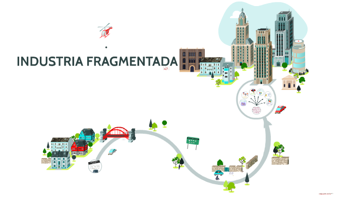

# 2 Características da indústria fragmentada

- Diversidade de empresas e competidores: Destaque para a variedade de empresas que operam na indústria fragmentada, incluindo tanto empresas grandes quanto pequenas, cada uma com sua própria especialização.
- Variedade de produtos, serviços e modelos de negócio: Abordagem da ampla gama de produtos, serviços e modelos de negócio presentes na indústria fragmentada, resultante da diversidade de empresas e segmentos.

# 3 Causas e fatores de fragmentação

- Barreiras de entrada relativamente baixas: Exploração de como as barreiras para ingresso no mercado são mais acessíveis em uma indústria fragmentada, permitindo que novas empresas entrem e concorram.
- Avanços tecnológicos e acesso a recursos: Discussão de como os avanços tecnológicos e o acesso a recursos facilitaram a fragmentação, permitindo que empresas menores se estabeleçam e operem eficientemente.
- Diversificação de demanda e preferências dos consumidores: Explicação de como a diversificação dos gostos e preferências dos consumidores impulsiona a fragmentação, pois as empresas buscam atender a demandas específicas.

# 4 Benefícios e desafios da fragmentação

- Maior competição e inovação: Destaque para como a fragmentação estimula a competição entre as empresas, levando a maior inovação, preços mais competitivos e maior variedade de produtos e serviços.
- Flexibilidade e adaptabilidade às mudanças: Explicação de como as empresas menores em uma indústria fragmentada tendem a ser mais ágeis e flexíveis, sendo capazes de se adaptar rapidamente às mudanças do mercado.
- Dificuldades de coordenação e colaboração entre empresas: Abordagem dos desafios relacionados à coordenação e colaboração entre empresas fragmentadas, devido à falta de uma autoridade central e à necessidade de alinhar interesses diversos.

# 5 Exemplos de setores industriais fragmentados

| Setor | Empresa |
| --- | --- |
| Alimentos e bebidas | Coca-Cola |
| Alimentos e bebidas | Nestlé |
| Alimentos e bebidas | Danone |
| Alimentos e bebidas | Heineken |
| Alimentos e bebidas | Kraft Heinz |
| Vestuário e moda | Zara |
| Vestuário e moda | H&M |
| Vestuário e moda | Nike |
| Vestuário e moda | Adidas |
| Vestuário e moda | Gucci |
| Tecnologia e eletrônicos | Apple |
| Tecnologia e eletrônicos | Samsung |
| Tecnologia e eletrônicos | Microsoft |
| Tecnologia e eletrônicos | Sony |
| Tecnologia e eletrônicos | Lenovo |
| Turismo e hospitalidade | Hilton |
| Turismo e hospitalidade | Marriott |
| Turismo e hospitalidade | Airbnb |
| Turismo e hospitalidade | Booking.com |
| Turismo e hospitalidade | TripAdvisor |

[figure not shown]

# 6 Impacto econômico e social da fragmentação

Impacto econômico e social da fragmentação:

- Geração de empregos e desenvolvimento local: Exploração de como a indústria fragmentada pode impulsionar a criação de empregos, especialmente em nível local, estimulando o crescimento econômico em diferentes regiões.
- Desafios para a sustentabilidade e responsabilidade social: Discussão dos desafios relacionados à sustentabilidade ambiental e à responsabilidade social nas empresas fragmentadas, devido à falta de uma governança centralizada.
- Influência nos padrões de consumo e comportamento do mercado: Abordagem de como a fragmentação da indústria pode influenciar os padrões de consumo e o comportamento do mercado, à medida que os consumidores têm acesso a uma ampla gama de opções e nichos específicos.

# 7 Estratégias para competir em uma indústria fragmentada

- Foco em segmentos de mercado específicos: Explicação de como as empresas podem obter vantagem competitiva ao concentrar-se em segmentos de mercado específicos, atendendo a necessidades e demandas exclusivas.
- Colaboração e parcerias estratégicas: Destaque para a importância da colaboração e das parcerias estratégicas entre empresas fragmentadas para melhorar a eficiência, compartilhar recursos e alcançar objetivos comuns.
- Inovação e diferenciação de produtos ou serviços: Abordagem de como a inovação contínua e a diferenciação são essenciais para se destacar em uma indústria fragmentada, oferecendo produtos ou serviços únicos e de alta qualidade.

# 8 Tendências e perspectivas futuras

- Consolidação versus contínua fragmentação: Discussão sobre as tendências futuras da indústria fragmentada, explorando se é provável que ocorra consolidação ou se a fragmentação continuará sendo uma característica predominante.
- Digitalização e comércio eletrônico: Abordagem de como a digitalização e o comércio eletrônico estão moldando a indústria fragmentada, facilitando a entrada de novos players e criando oportunidades para empresas menores.